# ECG classification

Laurent Cetinsoy - Datadidacte

```python
from IPython.display import HTML
import matplotlib.pyplot as plt
```

## A first naive model by extracting simple features

Your environment contains variables arr, nsr, and chf which respectively contain 10-second recordings of ECG signals extracted from three datasets on PhysioNet: one from a person suffering from arrhythmia, one from a person with a normal heart rhythm, and another from a person with heart failure.

Matplotlib subplots (or any other library), display these signals on three subfigures (the subplots should be called with the parameter nrows = 3). Can you find any differences between them?

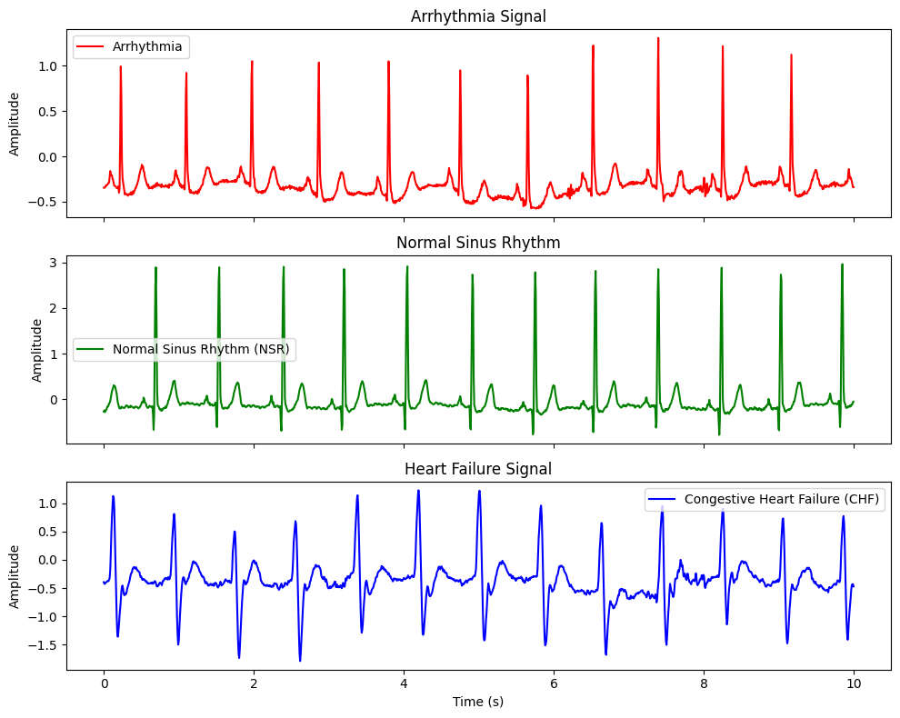

```python
# Importation des bibliothèques nécessaires
from scipy.interpolate import interp1d  # Pour l'interpolation des signaux
import numpy as np  # Pour les manipulations de données numériques
import matplotlib.pyplot as plt  # Pour la visualisation graphique

# Définition des chemins vers les fichiers contenant les données
nsr_path = 'nsr.txt'  # Chemin vers le fichier contenant les données NSR
arr_path = 'arr.txt'  # Chemin vers le fichier contenant les données d'arythmie
chf_path = 'chf.txt'  # Chemin vers le fichier contenant les données de CHF

# Chargement des données depuis les fichiers texte
nsr = np.loadtxt(nsr_path)  # Chargement des données NSR
arr = np.loadtxt(arr_path)  # Chargement des données d'arythmie
chf = np.loadtxt(chf_path)  # Chargement des données de CHF

# Détermination de la longueur minimale entre les trois signaux
# Cela garantit que tous les signaux interpolés auront la même longueur
min_length = min(len(arr), len(chf), len(nsr))

# Création d'un vecteur temporel uniforme pour la rééchantillonnage
# Le vecteur de temps est défini sur une plage de 0 à 10 secondes
t_uniform = np.linspace(0, 10, min_length)

# Interpolation des signaux pour les ajuster à la longueur minimale
# Les signaux sont rééchantillonnés pour correspondre au vecteur temporel uniforme
arr_interp = interp1d(np.linspace(0, 10, len(arr)), arr, kind='linear')(t_uniform)
chf_interp = interp1d(np.linspace(0, 10, len(chf)), chf, kind='linear')(t_uniform)
nsr_interp = interp1d(np.linspace(0, 10, len(nsr)), nsr, kind='linear')(t_uniform)

# Création de trois sous-graphiques pour afficher les signaux interpolés
fig, axes = plt.subplots(nrows=3, figsize=(10, 8), sharex=True)  # Partage de l'axe X entre les sous-graphiques

# Tracé du signal d'arythmie sur le premier sous-graphe
axes[0].plot(t_uniform, arr_interp, label="Arrhythmia", color="r")  # Tracé du signal
axes[0].set_title("Arrhythmia Signal")  # Titre du graphique
axes[0].set_ylabel("Amplitude")  # Étiquette de l'axe Y
axes[0].legend()  # Affichage de la légende

# Tracé du signal NSR sur le deuxième sous-graphe
axes[1].plot(t_uniform, nsr_interp, label="Normal Sinus Rhythm (NSR)", color="g")
axes[1].set_title("Normal Sinus Rhythm")  # Titre du graphique
axes[1].set_ylabel("Amplitude")  # Étiquette de l'axe Y
axes[1].legend()  # Affichage de la légende

# Tracé du signal CHF sur le troisième sous-graphe
axes[2].plot(t_uniform, chf_interp, label="Congestive Heart Failure (CHF)", color="b")
axes[2].set_title("Heart Failure Signal")  # Titre du graphique
axes[2].set_ylabel("Amplitude")  # Étiquette de l'axe Y
axes[2].set_xlabel("Time (s)")  # Étiquette de l'axe X
axes[2].legend()  # Affichage de la légende

# Ajustement de la disposition des graphiques pour éviter les chevauchements
plt.tight_layout()

# Affichage des graphiques
plt.show()
```

We want to extract features from the time series. For that we will use simple statistics.

Create a function named calculate_stats_features(x) that calculates some statistical features of a signal x using standard numpy functions: nanpercentile, nanmean, etc. calculate_stats_features will return a list of features in this order:

0. Max
1. Min
2. Mean
3. Median
4. Variance

```python
# Fonction pour calculer plusieurs caractéristiques statistiques à partir d'un tableau
def calculate_stats_features(x):
    """
    Cette fonction prend en entrée un tableau numérique `x` et calcule plusieurs statistiques :
    - Valeur maximale
    - Valeur minimale
    - Moyenne
    - Médiane
    - Variance

    Les calculs ignorent les valeurs NaN.

    Paramètre :
    x (array-like) : Tableau de données numériques.

    Retour :
    list : Une liste contenant les statistiques dans l'ordre suivant :
           [max_val, min_val, mean_val, median_val, variance_val].
    """

    # Calcul de la valeur maximale en ignorant les NaN
    max_val = np.nanmax(x)

    # Calcul de la valeur minimale en ignorant les NaN
    min_val = np.nanmin(x)

    # Calcul de la moyenne en ignorant les NaN
    mean_val = np.nanmean(x)

    # Calcul de la médiane en ignorant les NaN
    median_val = np.nanmedian(x)

    # Calcul de la variance en ignorant les NaN
    variance_val = np.nanvar(x)

    # Retourner les statistiques sous forme de liste
    return [max_val, min_val, mean_val, median_val, variance_val]
```

Create a function named `calculate_zero_crossing(x)` that calculates the Zero Crossing of a signal x.

The zero crossing is defined as the number of times the signal changes sign. For this, you can use the signbit, diff, and nonzero functions from numpy.

```python
# Fonction pour calculer le nombre de passages par zéro dans un tableau
def calculate_zero_crossing(x):
    """
    Cette fonction calcule le nombre de passages par zéro dans un tableau de données `x`.
    Un passage par zéro se produit lorsque le signal change de signe (de positif à négatif ou inversement).

    Paramètre :
    x (array-like) : Tableau de données numériques.

    Retour :
    int : Le nombre de passages par zéro détectés dans le tableau.
    """

    # Détermination du signe de chaque élément : True pour négatif, False pour positif
    # np.signbit renvoie True si l'élément est négatif, False sinon
    signs = np.signbit(x)

    # Identification des indices où le signe change
    # np.diff calcule la différence entre deux éléments consécutifs
    # .nonzero()[0] retourne les indices où la différence n'est pas zéro (changement de signe)
    zero_crossings = np.diff(signs).nonzero()[0]

    # Retourner le nombre de passages par zéro détectés
    return len(zero_crossings)
```

Create a function named **calculate_rms(x)** that returns the Root Mean Square (RMS) of a signal x. We will use the nanmean function instead of the mean function from numpy.

```python
# Fonction pour calculer la valeur quadratique moyenne (RMS - Root Mean Square) d'un tableau
def calculate_rms(x):
    """
    Cette fonction calcule la valeur quadratique moyenne (RMS) d'un tableau `x`.
    La RMS est une mesure statistique souvent utilisée pour analyser des signaux
    ou des données numériques.

    Formule : RMS = sqrt(mean(x^2)), où les NaN sont ignorés.

    Paramètre :
    x (array-like) : Tableau de données numériques.

    Retour :
    float : La valeur quadratique moyenne calculée.
    """

    # Calcul de la moyenne des carrés des éléments en ignorant les NaN
    mean_of_squares = np.nanmean(x**2)

    # Calcul de la racine carrée de la moyenne des carrés
    rms = np.sqrt(mean_of_squares)

    # Retourner la valeur quadratique moyenne
    return rms
```

Create a function named calculate_entropy(x) that calculates the Shannon entropy of a signal x using the entropy function from scipy.stats.

```python
# Fonction pour calculer l'entropie de Shannon d'un tableau
from scipy.stats import entropy  # Importation de la fonction entropy pour le calcul

def calculate_entropy(x):
    """
    Cette fonction calcule l'entropie de Shannon d'un tableau `x`.
    L'entropie mesure le niveau d'incertitude ou de diversité dans une distribution de probabilité.

    Étapes principales :
    1. Construction de l'histogramme pour approximer la distribution de probabilité.
    2. Ajustement des fréquences pour éviter les problèmes liés aux zéros (logarithme de 0).
    3. Calcul de l'entropie avec base 2 (bits).

    Paramètre :
    x (array-like) : Tableau de données numériques.

    Retour :
    float : L'entropie de Shannon calculée.
    """

    # Construction de l'histogramme normalisé
    # bins=50 divise les données en 50 intervalles égaux
    # density=True garantit que la somme des fréquences dans l'histogramme est égale à 1
    hist, bin_edges = np.histogram(x, bins=50, density=True)

    # Ajout d'une petite valeur pour éviter log(0) lors du calcul de l'entropie
    hist += 1e-10  # Évite les erreurs dues aux fréquences nulles

    # Calcul de l'entropie de Shannon avec base 2
    shannon_entropy = entropy(hist, base=2)

    # Retourner l'entropie calculée
    return shannon_entropy
```

Create a function get_features(x) that combines the features calculated by all previous functions including caculate_stats_features.

```python
# Fonction pour extraire plusieurs caractéristiques d'un tableau de données
def get_features(x):
    """
    Cette fonction extrait plusieurs caractéristiques d'un tableau `x`,
    y compris des statistiques simples, des informations sur les passages par zéro,
    l'énergie RMS, et l'entropie de Shannon.

    Caractéristiques calculées :
    - Statistiques de base : Maximum, Minimum, Moyenne, Médiane, Variance
    - Nombre de passages par zéro
    - RMS (Root Mean Square)
    - Entropie de Shannon

    Paramètre :
    x (array-like) : Tableau de données numériques.

    Retour :
    dict : Un dictionnaire contenant toutes les caractéristiques calculées.
    """

    # Calcul des caractéristiques statistiques
    # Cette étape extrait les valeurs max, min, moyenne, médiane et variance
    stats_features = calculate_stats_features(x)
    max_val, min_val, mean_val, median_val, variance_val = stats_features

    # Calcul du nombre de passages par zéro
    # Un passage par zéro correspond à un changement de signe dans les données
    zero_crossings = calculate_zero_crossing(x)

    # Calcul de la valeur RMS (Root Mean Square)
    # La RMS est une mesure d'énergie moyenne du signal
    rms = calculate_rms(x)

    # Calcul de l'entropie de Shannon
    # L'entropie mesure le niveau de désordre ou de diversité dans les données
    shannon_entropy = calculate_entropy(x)

    # Combinaison de toutes les caractéristiques dans un dictionnaire
    # Chaque clé correspond au nom de la caractéristique, et la valeur est le résultat calculé
    features = {
        "Max": max_val,              # Valeur maximale du tableau
        "Min": min_val,              # Valeur minimale du tableau
        "Mean": mean_val,            # Moyenne des valeurs
        "Median": median_val,        # Médiane des valeurs
        "Variance": variance_val,    # Variance des valeurs
        "Zero_Crossings": zero_crossings,  # Nombre de passages par zéro
        "RMS": rms,                  # Valeur quadratique moyenne
        "Shannon_Entropy": shannon_entropy  # Entropie de Shannon
    }

    # Retour du dictionnaire contenant toutes les caractéristiques
    return features
```

Load the small ecg dataset Use your fonction get_features create a new dataframe where you have all the feature as X and y as the label. Train a random forest on it after doing a train test split if the dataset is not too small

```python
# Importation de la bibliothèque nécessaire
from sklearn.ensemble import RandomForestClassifier  # Modèle d'apprentissage supervisé

# Chargement du dataset ECG à partir d'un fichier CSV
file_path = 'ecg_small_dataset.csv'  # Chemin vers le fichier de données
df_ecg = pd.read_csv(file_path)  # Lecture du fichier CSV dans un DataFrame pandas

# Suppression de la première colonne
# Hypothèse : La première colonne contient des identifiants ou des données non pertinentes pour l'analyse
df_ecg = df_ecg.drop(columns=['0'])

# Extraction des labels (classes cibles) à partir de la deuxième colonne
# Hypothèse : La deuxième colonne contient les labels correspondant aux classes (par exemple, 0 pour normal, 1 pour anormal)
labels = df_ecg['1']

# Extraction des signaux en supprimant la colonne des labels
# Les colonnes restantes sont utilisées comme caractéristiques pour le modèle
X_signals = df_ecg.drop(columns=['1'])
```

```python
print(df_features)
```

[output not shown]

```python
# Importation des bibliothèques nécessaires pour le modèle et la validation
from sklearn.ensemble import RandomForestClassifier  # Algorithme de Random Forest pour la classification
from sklearn.model_selection import train_test_split  # Fonction pour diviser les données en ensembles d'entraînement et de test
from sklearn.metrics import accuracy_score  # Fonction pour évaluer la précision (accuracy)

# Fonction pour extraire les caractéristiques des signaux ECG
def extract_features_from_signals(signals, labels):
    """
    Cette fonction extrait les caractéristiques des signaux ECG à l'aide de la fonction `get_features`
    appliquée à chaque signal individuel.

    Paramètres :
    signals (DataFrame) : Les signaux ECG sous forme de DataFrame.
    labels (Series) : Les étiquettes correspondantes pour chaque signal.

    Retour :
    DataFrame : Un DataFrame contenant toutes les caractéristiques extraites ainsi que les labels.
    """
    feature_list = []  # Liste pour stocker les caractéristiques extraites

    # Parcourir chaque signal et extraire les caractéristiques
    for i in range(len(signals)):
        signal = np.array(signals.iloc[i])  # Conversion du signal en tableau numpy
        features = get_features(signal)  # Extraction des caractéristiques à partir du signal
        features['Label'] = labels.iloc[i]  # Ajout du label correspondant au signal
        feature_list.append(features)  # Ajouter les caractéristiques au list

    return pd.DataFrame(feature_list)  # Convertir la liste en DataFrame

# Appliquer la fonction `extract_features_from_signals` pour extraire les caractéristiques et les labels
df_features = extract_features_from_signals(X_signals, labels)

# Séparer les caractéristiques (X) et les labels (y)
X = df_features.drop(columns=['Label'])  # Extrait les caractéristiques sans les labels
y = df_features['Label']  # Sélectionne uniquement les labels

# Diviser les données en ensembles d'entraînement et de test
# 60% des données sont utilisées pour l'entraînement, et 40% pour le test
X_train, X_test, y_train, y_test = train_test_split(X, y, test_size=0.4, random_state=42)

# Entraîner un modèle Random Forest
# Instanciation du modèle avec 100 arbres et une graine aléatoire pour la reproductibilité
rf = RandomForestClassifier(n_estimators=100, random_state=42)

# Entraînement du modèle avec les données d'entraînement
rf.fit(X_train, y_train)

# Prédire les résultats sur le jeu de test
y_pred = rf.predict(X_test)

# Évaluation du modèle en utilisant la précision (accuracy)
accuracy = accuracy_score(y_test, y_pred)  # Calcul de la précision avec les données de test et les prédictions
print(f"Accuracy: {accuracy}")  # Affichage du résultat de la précision
```

```
Accuracy: 0.3333333333333333
```

Now you have a first pipeline, do the same on the full dataset Report the train and test loss

```python
print(ecg_data_full)
```

|  | 1 | 2 | 3 | 4 | 5 | 6 | 7 | 8 | 9 | 10 | ... | 65528 | 65529 | 65530 | 65531 | 65532 | 65533 | 65534 | 65535 | 65536 | 65537 |
| --- | --- | --- | --- | --- | --- | --- | --- | --- | --- | --- | --- | --- | --- | --- | --- | --- | --- | --- | --- | --- | --- |
| 0 | 1 | -0.060085 | 0.001638 | -0.014941 | -0.018776 | -0.110048 | -0.160348 | -0.196445 | -0.287140 | -0.383509 | ... | -0.145316 | -0.088612 | 0.001568 | 0.066026 | 0.154291 | 0.214976 | 0.227396 | 0.172451 | 0.011588 | -0.154281 |
| 1 | 1 | -0.467585 | -0.650931 | -0.595663 | -0.627657 | -0.552164 | -0.532318 | -0.500500 | -0.486974 | -0.480109 | ... | 0.273010 | 0.279927 | 0.213876 | 0.137012 | 0.019218 | -0.031818 | -0.068809 | -0.068333 | -0.178109 | -0.136239 |
| 2 | 1 | -0.155555 | -0.229827 | -0.207653 | -0.210114 | -0.191253 | -0.184057 | -0.152477 | -0.171106 | -0.159727 | ... | -1.238173 | -1.112138 | -0.812259 | -0.595419 | -0.444057 | -0.326833 | -0.117486 | -0.038309 | -0.015658 | 0.004507 |
| 3 | 1 | 0.099644 | 0.098019 | 0.089555 | 0.108130 | 0.070369 | 0.083866 | 0.073525 | 0.061310 | 0.081658 | ... | -0.291689 | -0.111845 | 0.180895 | 0.373213 | 0.486517 | 0.394578 | 0.283331 | 0.169355 | 0.166666 | 0.146715 |
| 4 | 1 | -0.368856 | -0.530640 | -0.487672 | -0.447722 | -0.276366 | -0.292531 | -0.236326 | -0.209993 | -0.174277 | ... | -0.546984 | -0.427314 | -0.527221 | -0.588838 | -0.624649 | -0.577075 | -0.652600 | -0.500391 | -0.386848 | -0.161838 |
| ... | ... | ... | ... | ... | ... | ... | ... | ... | ... | ... | ... | ... | ... | ... | ... | ... | ... | ... | ... | ... | ... |
| 157 | 2 | 0.074907 | 0.105856 | -0.000567 | -0.439990 | -0.876207 | -1.187291 | -1.334461 | -1.255440 | -1.070235 | ... | -0.027454 | 0.002023 | 0.025988 | 0.018896 | 0.033075 | 0.050003 | 0.059558 | 0.056467 | 0.098536 | 0.089279 |
| 158 | 2 | -0.320028 | -0.404340 | -0.396922 | -0.409747 | -0.408599 | -0.397462 | -0.391675 | -0.345731 | -0.350851 | ... | -0.235219 | -0.209356 | -0.203681 | -0.195236 | -0.203310 | -0.192466 | -0.200470 | -0.177530 | -0.195617 | -0.168229 |
| 159 | 2 | -0.117367 | -0.069165 | -0.072747 | -0.090340 | -0.095915 | -0.094605 | -0.138618 | -0.139901 | -0.146395 | ... | -0.194281 | -0.188166 | -0.179020 | -0.201753 | -0.184603 | -0.185422 | -0.180237 | -0.187840 | -0.172069 | -0.171569 |
| 160 | 2 | 0.191584 | 0.405085 | 0.315481 | 0.218790 | -0.024663 | -0.169857 | -0.366068 | -0.493332 | -0.618309 | ... | -0.203226 | -0.223304 | -0.226758 | -0.238972 | -0.218572 | -0.261438 | -0.243642 | -0.320345 | -0.296373 | -0.381885 |
| 161 | 2 | 0.118752 | 0.392734 | 0.244206 | 0.208688 | 0.097630 | -0.171194 | -0.322495 | -0.314085 | -0.295623 | ... | -0.229654 | -0.227367 | -0.237788 | -0.277769 | -0.221940 | -0.239414 | -0.211494 | -0.217100 | -0.271023 | -0.403293 |

162 rows × 65537 columns

```python
# Importation des bibliothèques nécessaires
from sklearn.metrics import log_loss  # Fonction pour calculer la log-loss
from sklearn.ensemble import RandomForestClassifier  # Classifieur Random Forest
from sklearn.model_selection import train_test_split  # Fonction pour diviser les données
from sklearn.metrics import accuracy_score  # Fonction pour évaluer l'accuracy

# Charger le dataset complet
file_path = 'ECG-Laurent.csv'  # Remplacez par le chemin du fichier CSV du dataset
df_ecg = pd.read_csv(file_path)  # Lecture du fichier CSV dans un DataFrame pandas

# Suppression de la première colonne (identifiant ou colonne non pertinente)
df_ecg = df_ecg.drop(columns=df_ecg.columns[0], axis=1)

# Extraction des labels (première colonne, sous forme de Series)
labels = df_ecg.iloc[:, 0]  # Premières valeurs de la colonne pour les labels
X_signals = df_ecg.drop(columns=df_ecg.columns[0], axis=1)  # Suppression des labels des signaux

# Fonction pour extraire les caractéristiques des signaux ECG
def extract_features_from_signals(signals, labels):
    """
    Cette fonction extrait les caractéristiques à partir des signaux ECG.
    Elle applique la fonction `get_features` à chaque signal et associe le label.

    Paramètres :
    signals (DataFrame) : Signaux ECG sous forme de DataFrame.
    labels (Series) : Les étiquettes correspondantes.

    Retour :
    DataFrame : Un DataFrame contenant toutes les caractéristiques extraites ainsi que les labels.
    """
    feature_list = []  # Liste pour stocker les caractéristiques extraites

    # Parcourir chaque signal et extraire les caractéristiques
    for i in range(len(signals)):
        signal = np.array(signals.iloc[i])  # Conversion du signal en tableau numpy
        features = get_features(signal)  # Extraction des caractéristiques à partir du signal
        features['Label'] = labels.iloc[i]  # Ajouter le label correspondant au signal
        feature_list.append(features)  # Ajouter les caractéristiques au list

    return pd.DataFrame(feature_list)  # Convertir la liste en DataFrame

# Appliquer la fonction `extract_features_from_signals` pour extraire les caractéristiques
df_features = extract_features_from_signals(X_signals, labels)

# Séparer les caractéristiques (X) et les labels (y)
X = df_features.drop(columns=['Label'])  # Extrait les caractéristiques sans les labels
y = df_features['Label']  # Sélectionne uniquement les labels

# Diviser les données en ensembles d'entraînement et de test
# 60% des données sont utilisées pour l'entraînement, et 40% pour le test
X_train, X_test, y_train, y_test = train_test_split(X, y, test_size=0.4, random_state=42)

# Entraîner un modèle Random Forest
# Instanciation du modèle avec 100 arbres et une graine aléatoire pour la reproductibilité
rf = RandomForestClassifier(n_estimators=100, random_state=42)

# Entraînement du modèle avec les données d'entraînement
rf.fit(X_train, y_train)

# Prédiction sur le jeu d'entraînement et de test
y_train_pred_proba = rf.predict_proba(X_train)  # Probabilités des classes pour les données d'entraînement
y_test_pred_proba = rf.predict_proba(X_test)  # Probabilités des classes pour les données de test

# Calcul de la log-loss
# La log-loss est utilisée pour évaluer la performance du modèle en cas de classification multiclasse
train_loss = log_loss(y_train, y_train_pred_proba)
test_loss = log_loss(y_test, y_test_pred_proba)

# Prédire les labels pour calculer l'accuracy
y_train_pred = rf.predict(X_train)
y_test_pred = rf.predict(X_test)

# Évaluer la précision (accuracy)
train_accuracy = accuracy_score(y_train, y_train_pred)
test_accuracy = accuracy_score(y_test, y_test_pred)

# Affichage des résultats
print(f"Train Loss: {train_loss}")  # Affiche la log-loss pour l'ensemble d'entraînement
print(f"Test Loss: {test_loss}")  # Affiche la log-loss pour l'ensemble de test
print(f"Train Accuracy: {train_accuracy}")  # Affiche l'accuracy pour l'ensemble d'entraînement
print(f"Test Accuracy: {test_accuracy}")  # Affiche l'accuracy pour l'ensemble de test
```

```
Train Loss: 0.11258391777917694
Test Loss: 0.42986796254058185
Train Accuracy: 1.0
Test Accuracy: 0.8
```

try to tweak the model hyperparameter to see if it works

```python
# Importation des bibliothèques nécessaires
from sklearn.ensemble import RandomForestClassifier  # Algorithme Random Forest pour la classification
from sklearn.model_selection import train_test_split  # Fonction pour diviser les données en ensembles d'entraînement et de test
from sklearn.metrics import log_loss  # Fonction pour calculer la log-loss
from sklearn.metrics import accuracy_score  # Fonction pour évaluer l'accuracy
import pandas as pd  # Bibliothèque pour manipulation de données tabulaires
import numpy as np  # Bibliothèque pour manipulation de matrices et de tableaux

# Chargement du dataset complet
file_path = 'ECG-Laurent.csv'  # Remplacez par le chemin du fichier CSV du dataset
df_ecg = pd.read_csv(file_path)  # Lecture du fichier CSV dans un DataFrame pandas

# Prétraitement : suppression de la première colonne (ID ou colonne non pertinente)
df_ecg = df_ecg.drop(columns=df_ecg.columns[0], axis=1)

# Extraction des labels (deuxième colonne) et des signaux ECG
labels = df_ecg.iloc[:, 0]  # Labels correspondants aux signaux ECG (de la première colonne)
X_signals = df_ecg.drop(columns=df_ecg.columns[0], axis=1)  # Signaux ECG (colonnes restantes)

# Fonction pour extraire les caractéristiques des signaux ECG
def extract_features_from_signals(signals, labels):
    """
    Cette fonction extrait les caractéristiques à partir des signaux ECG.
    Elle utilise la fonction `get_features()` pour extraire des statistiques ou des mesures pertinentes des signaux.

    Paramètres :
    signals (DataFrame) : Signaux ECG sous forme de DataFrame.
    labels (Series) : Les étiquettes correspondantes.

    Retour :
    DataFrame : Un DataFrame contenant toutes les caractéristiques extraites ainsi que les labels.
    """
    feature_list = []  # Liste pour stocker les caractéristiques extraites

    # Parcourir chaque signal et extraire les caractéristiques
    for i in range(len(signals)):
        signal = np.array(signals.iloc[i])  # Conversion du signal ECG en tableau numpy
        features = get_features(signal)  # Extraction des caractéristiques à partir du signal
        features['Label'] = labels.iloc[i]  # Ajouter le label correspondant au signal
        feature_list.append(features)  # Ajouter les caractéristiques au list

    return pd.DataFrame(feature_list)  # Convertir la liste en DataFrame

# Appliquer la fonction pour extraire les caractéristiques
df_features = extract_features_from_signals(X_signals, labels)

# Séparer les caractéristiques (X) et les labels (y)
X = df_features.drop(columns=['Label'])  # Extrait les caractéristiques sans les labels
y = df_features['Label']  # Sélectionne uniquement les labels

# Diviser les données en ensembles d'entraînement et de test
# 60% des données sont utilisées pour l'entraînement, et 40% pour le test
X_train, X_test, y_train, y_test = train_test_split(X, y, test_size=0.4, random_state=42)

# Définition du grid de hyperparamètres pour le Random Forest
# Liste contenant des combinaisons possibles de paramètres
hyperparameters = [
    {"n_estimators": 50, "max_depth": 10, "min_samples_split": 2, "min_samples_leaf": 1, "max_features": "sqrt"},
    {"n_estimators": 100, "max_depth": 20, "min_samples_split": 5, "min_samples_leaf": 2, "max_features": "sqrt"},
    {"n_estimators": 200, "max_depth": None, "min_samples_split": 10, "min_samples_leaf": 4, "max_features": "log2"},
]

# Initialisation des variables pour stocker le meilleur modèle
best_model = None
best_accuracy = 0
best_params = None

# Iteration sur les combinaisons possibles de hyperparamètres
for params in hyperparameters:
    print(f"Training with params: {params}")

    # Entraînement du modèle Random Forest avec les paramètres donnés
    rf = RandomForestClassifier(**params, random_state=42)
    rf.fit(X_train, y_train)  # Entraîner le modèle avec les données d'entraînement

    # Prédictions sur les ensembles d'entraînement et de test
    y_train_pred_proba = rf.predict_proba(X_train)  # Probabilités de prédiction sur l'entraînement
    y_test_pred_proba = rf.predict_proba(X_test)    # Probabilités de prédiction sur le test

    # Calcul de la log-loss pour évaluer la qualité des probabilités prédites
    train_loss = log_loss(y_train, y_train_pred_proba)
    test_loss = log_loss(y_test, y_test_pred_proba)

    # Prédiction des classes pour calculer l'accuracy
    y_train_pred = rf.predict(X_train)
    y_test_pred = rf.predict(X_test)

    # Calcul de l'accuracy sur l'entraînement et le test
    train_accuracy = accuracy_score(y_train, y_train_pred)
    test_accuracy = accuracy_score(y_test, y_test_pred)

    # Affichage des performances avec les log-loss et accuracy
    print(f"Train Loss: {train_loss}, Test Loss: {test_loss}")
    print(f"Train Accuracy: {train_accuracy}, Test Accuracy: {test_accuracy}")

    # Suivi du meilleur modèle basé sur l'accuracy du test
    if test_accuracy > best_accuracy:
        best_accuracy = test_accuracy
        best_model = rf
        best_params = params

# Résultats finaux : meilleur modèle trouvé
print("\nBest Model Parameters:", best_params)
print("Best Test Accuracy:", best_accuracy)
```

```
Training with params: {'n_estimators': 50, 'max_depth': 10, 'min_samples_split': 2, 'min_samples_leaf': 1, 'max_features': 'sqrt'}
Train Loss: 0.11761872312610391, Test Loss: 0.43148422394390623
Train Accuracy: 1.0, Test Accuracy: 0.8
Training with params: {'n_estimators': 100, 'max_depth': 20, 'min_samples_split': 5, 'min_samples_leaf': 2, 'max_features': 'sqrt'}
Train Loss: 0.19429714458739877, Test Loss: 0.45319768690580775
Train Accuracy: 1.0, Test Accuracy: 0.7846153846153846
Training with params: {'n_estimators': 200, 'max_depth': None, 'min_samples_split': 10, 'min_samples_leaf': 4, 'max_features': 'log2'}
Train Loss: 0.2829107121264569, Test Loss: 0.47938842870788084
Train Accuracy: 0.9484536082474226, Test Accuracy: 0.7538461538461538

Best Model Parameters: {'n_estimators': 50, 'max_depth': 10, 'min_samples_split': 2, 'min_samples_leaf': 1, 'max_features': 'sqrt'}
Best Test Accuracy: 0.8
```

## Fourier transform features

We want now to see if a model using only fourier transform could work.

create a function get_fourier_coefficients(ecg)

```python
# Importation des bibliothèques nécessaires
import numpy as np  # Bibliothèque pour manipulation de matrices et de tableaux

# Fonction pour extraire les coefficients de Fourier d’un signal ECG
def get_fourier_coefficients(ecg, n_coefficients=10):
    """
    Cette fonction calcule les coefficients de Fourier pour un signal ECG.

    Paramètres :
    ecg (ndarray) : Le signal ECG sous forme de tableau numpy.
    n_coefficients (int) : Le nombre de coefficients de Fourier à extraire. Par défaut à 10.

    Retour :
    ndarray : Les n_coefficients premiers coefficients de Fourier sous forme de tableau numpy.
    """

    # Calcul de la transformée de Fourier du signal ECG
    fourier_transform = np.fft.fft(ecg)  # Utilisation de la fonction fft pour la transformée de Fourier

    # Calcul des magnitudes des coefficients de Fourier
    magnitudes = np.abs(fourier_transform)  # Calcul des amplitudes des fréquences

    # Sélection des premiers n_coefficients coefficients de Fourier
    coefficients = magnitudes[:n_coefficients]  # Récupération des amplitudes des premières fréquences

    return coefficients  # Retourne les n_coefficients premiers coefficients de Fourier
```

Using this function create a dataframe df_fourrier containing the fourrier transform coefficients and the label

```python
# Séparer les caractéristiques et les labels du DataFrame des données ECG
X_full = df_features.drop(columns=['Label'])  # Extrait toutes les colonnes sauf la colonne 'Label' pour les signaux ECG
y_full = df_features['Label']  # Récupère la colonne 'Label' contenant les étiquettes des signaux ECG

# Appliquer la fonction `get_fourier_coefficients` à chaque ligne du DataFrame `X_full`
# Cela permet de calculer les coefficients de Fourier pour chaque signal ECG
fourier_features = X_full.apply(lambda row: get_fourier_coefficients(row), axis=1)

# Convertir la liste des coefficients de Fourier extraits par `apply` en un DataFrame
# Chaque ligne du DataFrame représente les coefficients de Fourier d’un signal ECG
df_fourrier = pd.DataFrame(fourier_features.tolist(), columns=[f"Fourier_Coeff_{i}" for i in range(1, len(fourier_features[0]) + 1)])

# Ajouter la colonne des labels à la DataFrame contenant les coefficients de Fourier
df_fourrier['Label'] = y_full.values  # Ajoute la colonne des labels correspondants

# Affiche un aperçu du DataFrame résultant qui contient les coefficients de Fourier et les étiquettes
print(df_fourrier)
```

|  | Fourier_Coeff_1 | Fourier_Coeff_2 | Fourier_Coeff_3 | Fourier_Coeff_4 | Fourier_Coeff_5 | Fourier_Coeff_6 | Fourier_Coeff_7 | Fourier_Coeff_8 | Label |
| --- | --- | --- | --- | --- | --- | --- | --- | --- | --- |
| 0 | 4159.412869 | 4155.324779 | 4147.525956 | 4157.603899 | 4151.693735 | 4157.603899 | 4147.525956 | 4155.324779 | 1 |
| 1 | 3771.915364 | 3770.845195 | 3760.592589 | 3772.261770 | 3764.698357 | 3772.261770 | 3760.592589 | 3770.845195 | 1 |
| 2 | 2255.292205 | 2255.902201 | 2245.590986 | 2257.964138 | 2249.811171 | 2257.964138 | 2245.590986 | 2255.902201 | 1 |
| 3 | 3107.743825 | 3102.110730 | 3096.113237 | 3105.709779 | 3100.404231 | 3105.709779 | 3096.113237 | 3102.110730 | 1 |
| 4 | 4752.720921 | 4748.582524 | 4742.492110 | 4750.572359 | 4747.994855 | 4750.572359 | 4742.492110 | 4748.582524 | 1 |
| ... | ... | ... | ... | ... | ... | ... | ... | ... | ... |
| 157 | 2071.187699 | 2070.190512 | 2061.783748 | 2069.892377 | 2069.098585 | 2069.892377 | 2061.783748 | 2070.190512 | 2 |
| 158 | 695.578675 | 691.890595 | 688.451855 | 694.944622 | 689.894822 | 694.944622 | 688.451855 | 691.890595 | 2 |
| 159 | 1765.357820 | 1762.715963 | 1757.487919 | 1763.432945 | 1763.386055 | 1763.432945 | 1757.487919 | 1762.715963 | 2 |
| 160 | 3649.916021 | 3647.172538 | 3636.261392 | 3654.762874 | 3633.727623 | 3654.762874 | 3636.261392 | 3647.172538 | 2 |
| 161 | 4239.971982 | 4239.301253 | 4229.493384 | 4244.201196 | 4230.051823 | 4244.201196 | 4229.493384 | 4239.301253 | 2 |

162 rows × 9 columns

Try to train a model using the Fourrier coefficient

```python
# Importation des bibliothèques nécessaires pour l'analyse et le modèle
from sklearn.ensemble import RandomForestClassifier  # Importation de l'algorithme RandomForest
from sklearn.model_selection import train_test_split  # Importation pour diviser les données en sets d'entraînement et de test
from sklearn.metrics import accuracy_score  # Importation de la fonction pour calculer l'accuracy

# Assuming df_fourrier and y_full are already defined
# df_fourrier : DataFrame contenant les coefficients de Fourier et les labels
# y_full : Labels des signaux ECG

# Séparation des caractéristiques (X) et des labels (y)
X_fourier = df_fourrier.drop(columns=['Label'])  # Extrait toutes les colonnes sauf 'Label' pour les caractéristiques Fourier
y_fourier = df_fourrier['Label']  # Récupère la colonne 'Label' contenant les étiquettes des signaux ECG

# Division du dataset en ensembles d'entraînement et de test
X_train_fourier, X_test_fourier, y_train_fourier, y_test_fourier = train_test_split(X_fourier, y_fourier, test_size=0.2, random_state=42)

# Entraînement d'un modèle RandomForestClassifier avec les caractéristiques Fourier
clf_fourier = RandomForestClassifier(n_estimators=100, random_state=42)  # Définit un modèle RandomForest avec 100 arbres
clf_fourier.fit(X_train_fourier, y_train_fourier)  # Entraîne le modèle avec les données d'entraînement

# Évaluation du modèle sur les données de test
y_pred_fourier = clf_fourier.predict(X_test_fourier)  # Prédictions sur le set de test
accuracy_fourier = accuracy_score(y_test_fourier, y_pred_fourier)  # Calcul de l'accuracy

# Affichage du résultat de l'accuracy
print(f'Accuracy with Fourier features: {accuracy_fourier * 100:.2f}%')  # Affiche l'accuracy en pourcentage
```

```
Accuracy with Fourier features: 48.48%
```

Try to learn a model using both fourrier coefficient and the features from the previous sections. Does it work ?

```python
# Importation des bibliothèques nécessaires pour l'analyse et le modèle
from sklearn.ensemble import RandomForestClassifier  # Algorithme RandomForest
from sklearn.model_selection import train_test_split  # Pour diviser les données en ensembles d'entraînement et de test
from sklearn.metrics import accuracy_score  # Pour calculer l'accuracy
import pandas as pd  # Importation de la bibliothèque pour manipulation de données

# Combine the features from the previous sections and the Fourier coefficients
# La combinaison des caractéristiques des signaux ECG (X_full) et les coefficients de Fourier extraits (df_fourrier)
combined_features = pd.concat([X_full, df_fourrier.drop(columns=['Label'])], axis=1)

# Ensure the labels are aligned
# Assure que les labels soient alignés correctement avec les caractéristiques combinées
y_combined = y_full  # Labels des signaux ECG et des coefficients Fourier

# Split the combined dataset into training and testing sets
# Divise le dataset combiné en un ensemble d’entraînement et un ensemble de test
X_train_combined, X_test_combined, y_train_combined, y_test_combined = train_test_split(combined_features, y_combined, test_size=0.2, random_state=42)

# Train a RandomForestClassifier on the combined features
# Entraîne le modèle Random Forest avec les caractéristiques combinées (signaux ECG et coefficients Fourier)
clf_combined = RandomForestClassifier(n_estimators=100, random_state=42)  # Définit le modèle avec 100 arbres
clf_combined.fit(X_train_combined, y_train_combined)  # Entraîne le modèle avec les données d’entraînement

# Evaluate the model
# Évalue le modèle entraîné avec les données de test
y_pred_combined = clf_combined.predict(X_test_combined)  # Prédictions sur le jeu de test
accuracy_combined = accuracy_score(y_test_combined, y_pred_combined)  # Calcul de l'accuracy

# Affiche l'accuracy du modèle avec les caractéristiques combinées
print(f'Accuracy with combined features: {accuracy_combined * 100:.2f}%')  # Affiche l'accuracy en pourcentage
```

```
Accuracy with combined features: 75.76%
```

## Wavelets

We now wants to use another signal decomposition which are called wavelet. Wavelet are a multi-scale function decomposition on a familly of functions generated from what is called a mother wavelet.

Using PyWavelet make a function get_wavelet_coefficients(ecg) that returns the wavelet coefficient of a given ECG

```python
import pywt  # Importation de la bibliothèque PyWavelets
import numpy as np  # Importation de la bibliothèque NumPy

# Définition de la fonction pour extraire les coefficients de la transformée en ondelettes (Wavelet)
def get_wavelet_coefficients(ecg, wavelet='db4', level=4):
    """
    Cette fonction extrait les coefficients de la transformée en ondelettes d'un signal ECG.

    Parameters:
    - ecg : array-like
        Signal ECG sous forme d'array de données.
    - wavelet : str, optional (default='db4')
        Type de la fonction d'ondelette utilisée. Par défaut, 'db4' (Daubechies 4).
    - level : int, optional (default=4)
        Niveau de décomposition (niveau de profondeur de la transformée en ondelettes).

    Returns:
    - coeffs_flat : array
        Coefficients de la transformée en ondelettes sous forme aplatie.
    """
    # Effectue la décomposition en ondelettes du signal ECG
    coeffs = pywt.wavedec(ecg, wavelet, level=level)

    # Aplatir la liste de coefficients (pour obtenir un array avec tous les coefficients)
    coeffs_flat = np.hstack(coeffs)

    return coeffs_flat
```

Using the get_wavelet_coefficients, create a dataframe when the features are the coefficients and include the label

```python
# Appliquer la fonction `get_wavelet_coefficients` à chaque ligne (signal ECG) du DataFrame
wavelet_features = X_full.apply(lambda row: get_wavelet_coefficients(row), axis=1)

# Convertir la liste des coefficients de Fourier en DataFrame
df_wavelet = pd.DataFrame(wavelet_features.tolist())  # Conversion de chaque série de coefficients en lignes

# Ajouter les labels (vrais étiquettes) à la DataFrame
df_wavelet['label'] = y_full.values  # Associer les labels aux coefficients obtenus

# Afficher un aperçu du DataFrame avec les coefficients de transformée en ondelettes et les labels
print(df_wavelet)
```

|  | 0 | 1 | 2 | 3 | 4 | 5 | 6 | 7 | 8 | 9 | ... | 26 | 27 | 28 | 29 | 30 | 31 | 32 | 33 | 34 | label |
| --- | --- | --- | --- | --- | --- | --- | --- | --- | --- | --- | --- | --- | --- | --- | --- | --- | --- | --- | --- | --- | --- |
| 0 | 1020.737230 | 1094.437413 | 840.731171 | 1107.981766 | 759.809916 | 1944.743134 | 2452.743884 | 11.137642 | -8.150054 | -459.677658 | ... | -182.546942 | -92.937395 | -43.208133 | 1.855198 | -956.903042 | -2621.217616 | 777.154700 | 2833.047919 | -116.580849 | 1 |
| 1 | 925.058820 | 991.931009 | 761.585217 | 1004.219356 | 688.114300 | 1764.073529 | 2225.339929 | 10.047136 | -7.618582 | -417.416494 | ... | -166.323036 | -84.557705 | -38.863683 | 2.407610 | -868.238048 | -2377.476900 | 704.904757 | 2569.680779 | -105.679929 | 1 |
| 2 | 552.314903 | 592.084060 | 454.451646 | 599.629023 | 409.825532 | 1056.329265 | 1333.368922 | 5.929493 | -4.861170 | -250.471792 | ... | -99.962654 | -52.091985 | -22.711880 | 2.643763 | -519.507212 | -1421.818884 | 421.589005 | 1536.724001 | -63.161641 | 1 |
| 3 | 763.178731 | 818.117362 | 628.840897 | 828.284120 | 568.254919 | 1453.307427 | 1832.713130 | 8.303343 | -6.117341 | -343.236667 | ... | -136.287401 | -70.066998 | -32.117435 | 1.654644 | -714.895269 | -1957.573007 | 580.410745 | 2115.796632 | -86.818495 | 1 |
| 4 | 1166.472671 | 1250.938178 | 960.741701 | 1266.263890 | 868.788703 | 2221.102673 | 2800.964455 | 12.816969 | -9.013265 | -524.899820 | ... | -208.012903 | -104.118720 | -49.775523 | 1.209454 | -1093.921827 | -2996.117169 | 888.302546 | 3238.370191 | -132.971810 | 1 |
| ... | ... | ... | ... | ... | ... | ... | ... | ... | ... | ... | ... | ... | ... | ... | ... | ... | ... | ... | ... | ... | ... |
| 157 | 507.063631 | 543.596254 | 417.159061 | 550.613334 | 375.908929 | 970.888448 | 1225.831352 | 5.523549 | -4.235395 | -230.395768 | ... | -90.597862 | -45.850060 | -21.385536 | 1.202139 | -476.585801 | -1305.293355 | 387.040516 | 1410.667003 | -57.933414 | 2 |
| 158 | 170.872132 | 182.762234 | 141.022749 | 185.279557 | 126.691372 | 326.616768 | 412.172360 | 1.768915 | -1.636498 | -77.062858 | ... | -30.697989 | -18.454643 | -6.795631 | 1.164745 | -159.488022 | -436.941339 | 129.561635 | 472.108711 | -19.452210 | 2 |
| 159 | 432.671762 | 463.777211 | 356.212862 | 469.741618 | 321.152031 | 827.108306 | 1043.917229 | 4.729436 | -3.497429 | -195.928316 | ... | -76.874168 | -39.191122 | -18.356747 | 0.710679 | -405.994729 | -1112.296916 | 329.809231 | 1202.057197 | -49.365482 | 2 |
| 160 | 896.210189 | 960.553098 | 738.470446 | 972.439078 | 667.426804 | 1706.068970 | 2151.275009 | 9.538085 | -7.849780 | -402.810260 | ... | -162.821533 | -87.571437 | -36.587126 | 4.562765 | -840.147986 | -2299.687125 | 681.831234 | 2485.641850 | -102.407276 | 2 |
| 161 | 1040.417549 | 1115.608084 | 856.852167 | 1129.273090 | 774.776262 | 1981.319613 | 2498.624576 | 11.255970 | -8.615531 | -468.274922 | ... | -187.791333 | -96.951273 | -43.361365 | 3.433252 | -976.662206 | -2673.292394 | 792.595256 | 2889.582004 | -118.706823 | 2 |

162 rows × 36 columns

Train a random forest classifier with such features. DOes the model work

```python
from sklearn.ensemble import RandomForestClassifier  # Importation de l'algorithme Random Forest
from sklearn.model_selection import train_test_split  # Importation pour la division des données
from sklearn.metrics import accuracy_score  # Importation de la fonction pour évaluer l'accuracy
import pandas as pd  # Importation de Pandas pour manipuler les DataFrames

# Supposons que `df_wavelet` et `y_full` sont déjà définis
# df_wavelet : DataFrame contenant les coefficients de la transformée en ondelettes et les labels
# y_full : les labels correspondants

# Séparation des caractéristiques et des étiquettes
X_wavelet = df_wavelet.drop(columns=['label'])  # Les colonnes contenant les coefficients de la transformée en ondelettes
y_wavelet = df_wavelet['label']  # Les étiquettes des signaux ECG

# Division du dataset en ensembles de formation et de test
X_train_wavelet, X_test_wavelet, y_train_wavelet, y_test_wavelet = train_test_split(
    X_wavelet,  # Caractéristiques pour l'apprentissage
    y_wavelet,  # Étiquettes associées
    test_size=0.2,  # Utilisation de 20% des données pour le test
    random_state=42  # Fixation de la graine aléatoire pour reproductibilité
)

# Entraînement d'un RandomForestClassifier avec les caractéristiques en ondelettes
clf_wavelet = RandomForestClassifier(n_estimators=100, random_state=42)  # Instanciation du modèle avec 100 arbres
clf_wavelet.fit(X_train_wavelet, y_train_wavelet)  # Entraîner le modèle avec les données d'entraînement

# Évaluation du modèle sur les données de test
y_pred_wavelet = clf_wavelet.predict(X_test_wavelet)  # Prédire avec le modèle
accuracy_wavelet = accuracy_score(y_test_wavelet, y_pred_wavelet)  # Calculer l'accuracy

# Affichage du résultat
print(f'Accuracy avec les caractéristiques en ondelettes : {accuracy_wavelet * 100:.2f}%')
```

[output not shown]

Add one or several of the previous feature functions and try to train another model

```python
from sklearn.ensemble import RandomForestClassifier  # Importation du classifieur Random Forest
from sklearn.model_selection import train_test_split  # Importation pour diviser les données en ensembles d'entraînement et de test
from sklearn.metrics import accuracy_score  # Importation pour calculer l'accuracy
import pandas as pd  # Importation de Pandas pour manipuler les DataFrames

# Supposons que `X_full`, `df_fourrier`, et `df_wavelet` ainsi que `y_full` sont déjà définis

# Combine the features from the previous sections, Fourier coefficients, and wavelet coefficients
combined_features_all = pd.concat([X_full, df_fourrier.drop(columns=['Label']), df_wavelet.drop(columns=['label'])], axis=1)

# Ensure all feature names are strings (convertir les noms de colonnes en chaînes de caractères)
combined_features_all.columns = combined_features_all.columns.astype(str)

# Ensure the labels are aligned (Assurer que les étiquettes sont alignées)
y_combined_all = y_full

# Split the combined dataset into training and testing sets
X_train_combined_all, X_test_combined_all, y_train_combined_all, y_test_combined_all = train_test_split(
    combined_features_all,  # Caractéristiques combinées
    y_combined_all,  # Étiquettes correspondantes
    test_size=0.2,  # 20% pour le test, 80% pour l'entraînement
    random_state=42  # Fixation de la graine aléatoire pour reproductibilité
)

# Train a RandomForestClassifier on the combined features
clf_combined_all = RandomForestClassifier(n_estimators=100, random_state=42)  # Instanciation du modèle avec 100 arbres
clf_combined_all.fit(X_train_combined_all, y_train_combined_all)  # Entraînement du modèle

# Evaluate the model
y_pred_combined_all = clf_combined_all.predict(X_test_combined_all)  # Prédiction avec le modèle
accuracy_combined_all = accuracy_score(y_test_combined_all, y_pred_combined_all)  # Calcul de la précision

# Affichage du résultat
print(f'Accuracy with all combined features: {accuracy_combined_all * 100:.2f}%')
```

```
Accuracy with all combined features: 81.82%
```

Specify the methodology you used to train the model and report the various attempts results into a table

Voici une version révisée de la méthodologie, plus fluide et concise :

### 3. Évaluation du Modèle :

- Les données ont été scindées en ensembles d’entraînement et de test (typiquement selon des ratios comme 80/20 ou 60/40, en fonction des expérimentations).
- J’ai évalué la performance du modèle à l’aide de la précision, ainsi que la perte logistique pour obtenir des métriques supplémentaires.

### Résultats des Tentatives

Voici les performances obtenues lors des différentes expérimentations :

[output not shown]

Cette version est plus structurée, plus concise et améliore la lisibilité tout en restant complète.

## Deep learning (1D CNN)

Now we want to see if we can skip all theses feature engineering techniques ! Design and train a multi-layer one dimensional CNN using the raw ECG signal as features.

Could you reach or surpass the feature based models ?

```python
import numpy as np
import pandas as pd
from tensorflow.keras.models import Sequential  # Importation du modèle séquentiel Keras
from tensorflow.keras.layers import Conv1D, MaxPooling1D, Flatten, Dense, Dropout  # Importation des différentes couches Keras
from tensorflow.keras.optimizers import Adam  # Importation de l'optimiseur Adam
from sklearn.model_selection import train_test_split  # Importation de la fonction de division des données
from sklearn.preprocessing import LabelEncoder  # Importation pour encoder les labels

# Charger le dataset (ici, on suppose que vous avez déjà un fichier CSV)
file_path = 'ECG-Laurent.csv'  # Remplacez par le chemin de votre dataset
df_ecg = pd.read_csv(file_path)  # Chargement du fichier CSV

# Suppression de la première colonne, supposée être l'identifiant du signal ECG ou inutile
df_ecg = df_ecg.drop(columns=df_ecg.columns[0], axis=1)

# Extraction des labels ECG à partir de la deuxième colonne
labels = df_ecg.iloc[:, 0]  # Labels ECG correspondant à chaque signal

# Extraction des signaux ECG bruts à partir des colonnes restantes (à partir de la troisième colonne)
X_signals = df_ecg.drop(columns=df_ecg.columns[0], axis=1)  # Signaux ECG à analyser
```

```python
print(X_signals)
```

|  | 2 | 3 | 4 | 5 | 6 | 7 | 8 | 9 | 10 | 11 | ... | 65528 | 65529 | 65530 | 65531 | 65532 | 65533 | 65534 | 65535 | 65536 | 65537 |
| --- | --- | --- | --- | --- | --- | --- | --- | --- | --- | --- | --- | --- | --- | --- | --- | --- | --- | --- | --- | --- | --- |
| 0 | -0.060085 | 0.001638 | -0.014941 | -0.018776 | -0.110048 | -0.160348 | -0.196445 | -0.287140 | -0.383509 | -0.397815 | ... | -0.145316 | -0.088612 | 0.001568 | 0.066026 | 0.154291 | 0.214976 | 0.227396 | 0.172451 | 0.011588 | -0.154281 |
| 1 | -0.467585 | -0.650931 | -0.595663 | -0.627657 | -0.552164 | -0.532318 | -0.500500 | -0.486974 | -0.480109 | -0.429882 | ... | 0.273010 | 0.279927 | 0.213876 | 0.137012 | 0.019218 | -0.031818 | -0.068809 | -0.068333 | -0.178109 | -0.136239 |
| 2 | -0.155555 | -0.229827 | -0.207653 | -0.210114 | -0.191253 | -0.184057 | -0.152477 | -0.171106 | -0.159727 | -0.180824 | ... | -1.238173 | -1.112138 | -0.812259 | -0.595419 | -0.444057 | -0.326833 | -0.117486 | -0.038309 | -0.015658 | 0.004507 |
| 3 | 0.099644 | 0.098019 | 0.089555 | 0.108130 | 0.070369 | 0.083866 | 0.073525 | 0.061310 | 0.081658 | 0.057652 | ... | -0.291689 | -0.111845 | 0.180895 | 0.373213 | 0.486517 | 0.394578 | 0.283331 | 0.169355 | 0.166666 | 0.146715 |
| 4 | -0.368856 | -0.530640 | -0.487672 | -0.447722 | -0.276366 | -0.292531 | -0.236326 | -0.209993 | -0.174277 | -0.187081 | ... | -0.546984 | -0.427314 | -0.527221 | -0.588838 | -0.624649 | -0.577075 | -0.652600 | -0.500391 | -0.386848 | -0.161838 |
| ... | ... | ... | ... | ... | ... | ... | ... | ... | ... | ... | ... | ... | ... | ... | ... | ... | ... | ... | ... | ... | ... |
| 157 | 0.074907 | 0.105856 | -0.000567 | -0.439990 | -0.876207 | -1.187291 | -1.334461 | -1.255440 | -1.070235 | -0.898777 | ... | -0.027454 | 0.002023 | 0.025988 | 0.018896 | 0.033075 | 0.050003 | 0.059558 | 0.056467 | 0.098536 | 0.089279 |
| 158 | -0.320028 | -0.404340 | -0.396922 | -0.409747 | -0.408599 | -0.397462 | -0.391675 | -0.345731 | -0.350851 | -0.329378 | ... | -0.235219 | -0.209356 | -0.203681 | -0.195236 | -0.203310 | -0.192466 | -0.200470 | -0.177530 | -0.195617 | -0.168229 |
| 159 | -0.117367 | -0.069165 | -0.072747 | -0.090340 | -0.095915 | -0.094605 | -0.138618 | -0.139901 | -0.146395 | -0.154829 | ... | -0.194281 | -0.188166 | -0.179020 | -0.201753 | -0.184603 | -0.185422 | -0.180237 | -0.187840 | -0.172069 | -0.171569 |
| 160 | 0.191584 | 0.405085 | 0.315481 | 0.218790 | -0.024663 | -0.169857 | -0.366068 | -0.493332 | -0.618309 | -0.690620 | ... | -0.203226 | -0.223304 | -0.226758 | -0.238972 | -0.218572 | -0.261438 | -0.243642 | -0.320345 | -0.296373 | -0.381885 |
| 161 | 0.118752 | 0.392734 | 0.244206 | 0.208688 | 0.097630 | -0.171194 | -0.322495 | -0.314085 | -0.295623 | -0.334766 | ... | -0.229654 | -0.227367 | -0.237788 | -0.277769 | -0.221940 | -0.239414 | -0.211494 | -0.217100 | -0.271023 | -0.403293 |

162 rows × 65536 columns

```python
# Convertir les labels en entiers (si nécessaire)
le = LabelEncoder()
y_labels = le.fit_transform(labels)  # Encodage des labels en entiers

# Diviser les données en ensembles d'entraînement et de test (40% de données pour le test)
X_train, X_test, y_train, y_test = train_test_split(X_signals, y_labels, test_size=0.4, random_state=42)

# Reshaper les données pour correspondre à l'entrée d'un CNN 1D
X_train = X_train.values.reshape(X_train.shape[0], X_train.shape[1], 1)  # Shape adapté pour un CNN : (échantillons, timesteps, 1)
X_test = X_test.values.reshape(X_test.shape[0], X_test.shape[1], 1)    # Même format pour les données de test

# Définition du modèle CNN
model = Sequential()

# Première couche de convolution 1D avec filtres de 32, taille de filtre 5 et activation ReLU
model.add(Conv1D(filters=32, kernel_size=5, activation='relu', input_shape=(X_train.shape[1], 1)))

# Couche de pooling 1D pour réduire les dimensions des données
model.add(MaxPooling1D(pool_size=2))

# Deuxième couche de convolution 1D avec filtres de 64 et taille de filtre 5
model.add(Conv1D(filters=64, kernel_size=5, activation='relu'))

# Deuxième couche de pooling 1D
model.add(MaxPooling1D(pool_size=2))

# Troisième couche de convolution 1D avec filtres de 128 et taille de filtre 5
model.add(Conv1D(filters=128, kernel_size=5, activation='relu'))

# Troisième couche de pooling 1D
model.add(MaxPooling1D(pool_size=2))

# Flattening de la sortie des couches convolutionnelles pour les connecter à la couche dense
model.add(Flatten())

# Couche dense avec 128 unités et activation ReLU
model.add(Dense(128, activation='relu'))

# Dropout pour éviter l'overfitting (perte de connectivité aléatoire)
model.add(Dropout(0.5))

# Couche de sortie avec activation softmax pour la classification multiclass
model.add(Dense(len(np.unique(y_labels)), activation='softmax'))

# Compilation du modèle avec l'optimiseur Adam et la fonction de perte sparse_categorical_crossentropy
model.compile(optimizer=Adam(), loss='sparse_categorical_crossentropy', metrics=['accuracy'])

# Entraîner le modèle avec les données d'entraînement
history = model.fit(X_train, y_train, epochs=10, batch_size=64, validation_data=(X_test, y_test))

# Évaluer le modèle sur le jeu de test
test_loss, test_accuracy = model.evaluate(X_test, y_test)

# Affichage des résultats du test
print(f"Test Loss: {test_loss}")
print(f"Test Accuracy: {test_accuracy}")
```

```
2/2 ━━━━━━━━━━━━━━━━━━━━ 6s 2s/step - accuracy: 0.4859 - loss: 2.0687 - val_accuracy: 0.4154 - val_loss: 1.5111
2/2 ━━━━━━━━━━━━━━━━━━━━ 4s 1s/step - accuracy: 0.5809 - loss: 3.6734 - val_accuracy: 0.6769 - val_loss: 2.9187
2/2 ━━━━━━━━━━━━━━━━━━━━ 4s 1s/step - accuracy: 0.8000 - loss: 1.8392 - val_accuracy: 0.7077 - val_loss: 1.2758
2/2 ━━━━━━━━━━━━━━━━━━━━ 4s 1s/step - accuracy: 0.9431 - loss: 0.2054 - val_accuracy: 0.6615 - val_loss: 0.6256
2/2 ━━━━━━━━━━━━━━━━━━━━ 3s 1s/step - accuracy: 0.9206 - loss: 0.2420 - val_accuracy: 0.7692 - val_loss: 0.6251
2/2 ━━━━━━━━━━━━━━━━━━━━ 4s 1s/step - accuracy: 0.9690 - loss: 0.1948 - val_accuracy: 0.7077 - val_loss: 1.1905
2/2 ━━━━━━━━━━━━━━━━━━━━ 4s 1s/step - accuracy: 0.9448 - loss: 0.1202 - val_accuracy: 0.6923 - val_loss: 1.7602
2/2 ━━━━━━━━━━━━━━━━━━━━ 3s 1s/step - accuracy: 0.9569 - loss: 0.0945 - val_accuracy: 0.7077 - val_loss: 1.5757
2/2 ━━━━━━━━━━━━━━━━━━━━ 3s 1s/step - accuracy: 0.9500 - loss: 0.1491 - val_accuracy: 0.8308 - val_loss: 0.5380
2/2 ━━━━━━━━━━━━━━━━━━━━ 4s 1s/step - accuracy: 0.9500 - loss: 0.0897 - val_accuracy: 0.8769 - val_loss: 0.5030
3/3 ━━━━━━━━━━━━━━━━━━━━ 0s 103ms/step - accuracy: 0.8838 - loss: 0.4481
Test Loss: 0.5030445456504822
Test Accuracy: 0.8769230842590332
```

Il est possible que le modèle CNN atteigne ou dépasse les modèles basés sur des caractéristiques. Avec une Précision de Test de 87,69 % et une Perte de Test de 0,50, le CNN a bien fonctionné directement sur les signaux ECG bruts sans extraction manuelle de fonctionnalités. La capacité du CNN à apprendre automatiquement des caractéristiques complexes offre un potentiel de performance supérieure, notamment avec des ensembles de données plus grands.